# 1.14

Фокина Дарья

Известны наблюдения над различными участками Солнца. Надо построить модель, предсказывающую число вспышек в следующие 24 часа. Считываем данные:

```r
solar.flares <- read.csv('solar flares.csv',sep = ';')
print(solar.flares)
```

| modified.Zurich.class | largest.spot.size | spot.distribution | Activity | Evolution | Previous.24.hour.flare.activity.code | Historically.complex | Did.region.become.historically.complex.on.this.pass.across.the.sun.s.disk | Area | C.class.flares.production.by.this.region.in.the.following.24.hours..common.flares. | M.class.flares.production.by.this.region.in.the.following.24.hours..moderate.flares. | X.class.flares.production.by.this.region.in.the.following.24.hours..severe.flares. |
| --- | --- | --- | --- | --- | --- | --- | --- | --- | --- | --- | --- |
| H | A | X | reduced | growth | nothing as big as an M1 | yes | yes | small | 0 | 0 | 0 |
| D | R | O | reduced | growth | nothing as big as an M1 | yes | no | small | 0 | 0 | 0 |
| C | S | O | reduced | growth | nothing as big as an M1 | yes | no | small | 0 | 0 | 0 |
| H | R | X | reduced | no growth | nothing as big as an M1 | yes | yes | small | 0 | 0 | 0 |
| H | S | X | reduced | decay | nothing as big as an M1 | yes | no | small | 0 | 0 | 0 |
| C | A | O | reduced | no growth | nothing as big as an M1 | yes | no | small | 0 | 0 | 0 |
| B | X | O | reduced | growth | nothing as big as an M1 | yes | no | small | 0 | 0 | 0 |
| C | A | O | reduced | growth | nothing as big as an M1 | yes | no | small | 0 | 0 | 0 |
| C | A | O | reduced | no growth | nothing as big as an M1 | yes | no | small | 1 | 0 | 0 |
| B | X | O | reduced | growth | nothing as big as an M1 | yes | no | small | 0 | 0 | 0 |

[output cut: 990 more lines]

```r
print(colnames(solar.flares))
```

```
 [1] "modified.Zurich.class"
 [2] "largest.spot.size"
 [3] "spot.distribution"
 [4] "Activity"
 [5] "Evolution"
 [6] "Previous.24.hour.flare.activity.code"
 [7] "Historically.complex"
 [8] "Did.region.become.historically.complex.on.this.pass.across.the.sun.s.disk"
 [9] "Area"
[10] "C.class.flares.production.by.this.region.in.the.following.24.hours..common.flares."
[11] "M.class.flares.production.by.this.region.in.the.following.24.hours..moderate.flares."
[12] "X.class.flares.production.by.this.region.in.the.following.24.hours..severe.flares."
```

```r
print(ncol(solar.flares))
```

```
[1] 12
```

Всего 9 признаков. Все признаки категориальные. Последние столбцы - число вспышек различной степени, т.е. отклик.

## 1. Преобразование данных

Cуммарное число вспышек за 24 часа на каждом участке:

```r
solar.flares$sum.of.flares.production.by.this.region.24.hours <- rowSums(solar.flares[,c(10,11,12)])
```

Удалим ненужные столбцы:

```r
solar.flares <- solar.flares[,!(colnames(solar.flares) %in% c("C.class.flares.production.by.this.region.in.the.following.24.hours..common.flares.","M.class.flares.production.by.this.region.in.the.following.24.hours..moderate.flares.","X.class.flares.production.by.this.region.in.the.following.24.hours..severe.flares."))]
```

Визуализация данных:

```r
par(mfrow=c(2,2))
boxplot(sum.of.flares.production.by.this.region.24.hours ~ modified.Zurich.class,data=solar.flares)
boxplot(sum.of.flares.production.by.this.region.24.hours ~ largest.spot.size,data = solar.flares)
```

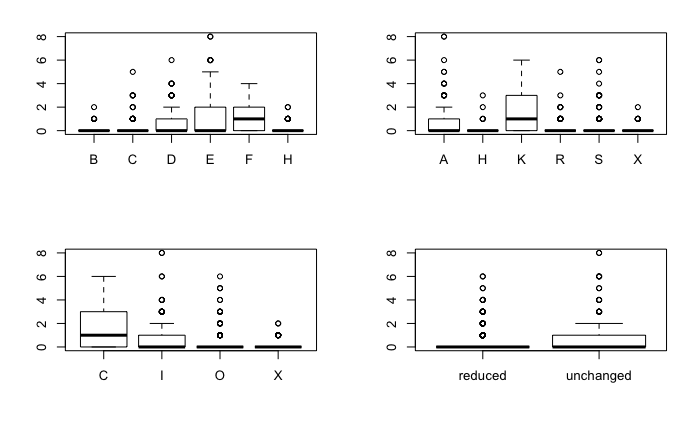

```r
boxplot(sum.of.flares.production.by.this.region.24.hours ~ spot.distribution,data = solar.flares)
boxplot(sum.of.flares.production.by.this.region.24.hours ~ Activity, data = solar.flares)
```

```r
par(mfrow=c(2,2))
boxplot(sum.of.flares.production.by.this.region.24.hours ~ Evolution,data=solar.flares)
boxplot(sum.of.flares.production.by.this.region.24.hours ~ Previous.24.hour.flare.activity.code,data=solar.flares)
```

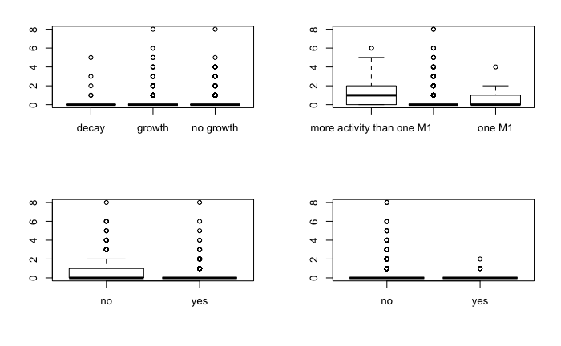

```r
boxplot(sum.of.flares.production.by.this.region.24.hours ~ Historically.complex,data = solar.flares)
boxplot(sum.of.flares.production.by.this.region.24.hours ~ Did.region.become.historically.complex.on.this.pass.across.the.sun.s.disk,data = solar.flares)
```

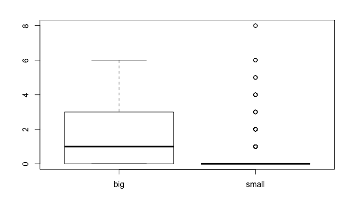

```r
boxplot(sum.of.flares.production.by.this.region.24.hours ~ Area,data = solar.flares)
```

Отклик больше 6 - выброс.

```r
solar.flares <- solar.flares[which(solar.flares$sum.of.flares.production.by.this.region.24.hours < 7),]
```

Видно, что признаки “Activity”,“Historically.complex”, “Did.region.become.historically.complex.on.this.pass.across.the.sun.s.disk”, “Area” - бинарные. Заменим их на 0 и 1:

```r
tmp <-  solar.flares$Activity
solar.flares$Activity <- as.integer(I(tmp == "unchanged"))
tmp <- solar.flares$Historically.complex
solar.flares$Historically.complex <- as.integer(I(tmp == "yes"))
tmp <- solar.flares$Did.region.become.historically.complex.on.this.pass.across.the.sun.s.disk
solar.flares$Did.region.become.historically.complex.on.this.pass.across.the.sun.s.disk <- as.integer(I(tmp == "yes"))
tmp <- solar.flares$Area
solar.flares$Area <-as.integer(I(tmp == "big"))
```

В признаках “Evolution”, “Previous.24.hour.flare.activity.code” 3 значения, заменим их на -1,0,1 и 1,2,3 соответственно:

```r
solar.flares$Evolution <- as.numeric(factor(solar.flares$Evolution,levels = c("decay", "no growth", "growth")))-2
solar.flares$Previous.24.hour.flare.activity.code <- as.numeric(factor(solar.flares$Previous.24.hour.flare.activity.code,levels = c("nothing as big as an M1","one M1","more activity than one M1")))
```

С помощью dummyVars заменим остальные категориальные признаки на числовые:

```r
library(caret)
newvar = dummyVars(~ .,fullRank = TRUE, data = solar.flares)
solar.flares.modified <-  predict(newvar, newdata = solar.flares)
detach("package:caret", unload=TRUE)
```

```r
solar.flares.modified <- data.frame(solar.flares.modified)
print(solar.flares.modified)
```

|  | modified.Zurich.class.C | modified.Zurich.class.D | modified.Zurich.class.E | modified.Zurich.class.F | modified.Zurich.class.H | largest.spot.size.H | largest.spot.size.K | largest.spot.size.R | largest.spot.size.S | largest.spot.size.X | spot.distribution.I | spot.distribution.O | spot.distribution.X | Activity | Evolution | Previous.24.hour.flare.activity.code | Historically.complex | Did.region.become.historically.complex.on.this.pass.across.the.sun.s.disk | Area | sum.of.flares.production.by.this.region.24.hours |
| --- | --- | --- | --- | --- | --- | --- | --- | --- | --- | --- | --- | --- | --- | --- | --- | --- | --- | --- | --- | --- |
| 1 | 0 | 0 | 0 | 0 | 1 | 0 | 0 | 0 | 0 | 0 | 0 | 0 | 1 | 0 | 1 | 1 | 1 | 1 | 0 | 0 |
| 2 | 0 | 1 | 0 | 0 | 0 | 0 | 0 | 1 | 0 | 0 | 0 | 1 | 0 | 0 | 1 | 1 | 1 | 0 | 0 | 0 |
| 3 | 1 | 0 | 0 | 0 | 0 | 0 | 0 | 0 | 1 | 0 | 0 | 1 | 0 | 0 | 1 | 1 | 1 | 0 | 0 | 0 |
| 4 | 0 | 0 | 0 | 0 | 1 | 0 | 0 | 1 | 0 | 0 | 0 | 0 | 1 | 0 | 0 | 1 | 1 | 1 | 0 | 0 |
| 5 | 0 | 0 | 0 | 0 | 1 | 0 | 0 | 0 | 1 | 0 | 0 | 0 | 1 | 0 | -1 | 1 | 1 | 0 | 0 | 0 |
| 6 | 1 | 0 | 0 | 0 | 0 | 0 | 0 | 0 | 0 | 0 | 0 | 1 | 0 | 0 | 0 | 1 | 1 | 0 | 0 | 0 |
| 7 | 0 | 0 | 0 | 0 | 0 | 0 | 0 | 0 | 0 | 1 | 0 | 1 | 0 | 0 | 1 | 1 | 1 | 0 | 0 | 0 |
| 8 | 1 | 0 | 0 | 0 | 0 | 0 | 0 | 0 | 0 | 0 | 0 | 1 | 0 | 0 | 1 | 1 | 1 | 0 | 0 | 0 |
| 9 | 1 | 0 | 0 | 0 | 0 | 0 | 0 | 0 | 0 | 0 | 0 | 1 | 0 | 0 | 0 | 1 | 1 | 0 | 0 | 1 |
| 10 | 0 | 0 | 0 | 0 | 0 | 0 | 0 | 0 | 0 | 1 | 0 | 1 | 0 | 0 | 1 | 1 | 1 | 0 | 0 | 0 |

[output cut: 990 more lines]

## 2. Построение моделей

```r
model0 <- glm(sum.of.flares.production.by.this.region.24.hours~1, family = poisson,data=solar.flares.modified)
add1(model0, names(solar.flares.modified), test="LRT")
```

```
отклик появился справа и поэтому был удаленпроблема с термом 20 в 'model.matrix': не присвоены колонки
```

```
Single term additions

Model:
sum.of.flares.production.by.this.region.24.hours ~ 1
                                                                          Df Deviance    AIC
<none>                                                                         1347.0 1821.8
modified.Zurich.class.C                                                    1   1332.3 1809.0
modified.Zurich.class.D                                                    1   1320.3 1797.0
modified.Zurich.class.E                                                    1   1195.9 1672.6
modified.Zurich.class.F                                                    1   1306.0 1782.7
modified.Zurich.class.H                                                    1   1209.4 1686.1
largest.spot.size.H                                                        1   1347.0 1823.8
largest.spot.size.K                                                        1   1208.4 1685.1
largest.spot.size.R                                                        1   1316.7 1793.4
largest.spot.size.S                                                        1   1324.3 1801.0
largest.spot.size.X                                                        1   1302.5 1779.2
spot.distribution.I                                                        1   1243.4 1720.1
spot.distribution.O                                                        1   1326.3 1803.0
spot.distribution.X                                                        1   1209.4 1686.1
Activity                                                                   1   1220.8 1697.5
Evolution                                                                  1   1330.8 1807.5
Previous.24.hour.flare.activity.code                                       1   1284.8 1761.5
Historically.complex                                                       1   1252.6 1729.3
Did.region.become.historically.complex.on.this.pass.across.the.sun.s.disk  1   1300.1 1776.8
Area                                                                       1   1261.0 1737.7
sum.of.flares.production.by.this.region.24.hours                           0   1347.0 1821.8
                                                                              LRT  Pr(>Chi)
<none>
modified.Zurich.class.C                                                    14.713 0.0001252 ***
modified.Zurich.class.D                                                    26.789 2.269e-07 ***
modified.Zurich.class.E                                                   151.161 < 2.2e-16 ***
modified.Zurich.class.F                                                    41.071 1.468e-10 ***
modified.Zurich.class.H                                                   137.676 < 2.2e-16 ***
largest.spot.size.H                                                         0.002 0.9637356
largest.spot.size.K                                                       138.633 < 2.2e-16 ***
largest.spot.size.R                                                        30.363 3.583e-08 ***
largest.spot.size.S                                                        22.796 1.802e-06 ***
largest.spot.size.X                                                        44.576 2.446e-11 ***
spot.distribution.I                                                       103.681 < 2.2e-16 ***
spot.distribution.O                                                        20.727 5.296e-06 ***
spot.distribution.X                                                       137.676 < 2.2e-16 ***
Activity                                                                  126.248 < 2.2e-16 ***
Evolution                                                                  16.289 5.438e-05 ***
Previous.24.hour.flare.activity.code                                       62.255 3.017e-15 ***
Historically.complex                                                       94.474 < 2.2e-16 ***
Did.region.become.historically.complex.on.this.pass.across.the.sun.s.disk  46.996 7.113e-12 ***
Area                                                                       86.013 < 2.2e-16 ***
sum.of.flares.production.by.this.region.24.hours                            0.000
---
Signif. codes:  0 ‘***’ 0.001 ‘**’ 0.01 ‘*’ 0.05 ‘.’ 0.1 ‘ ’ 1
```

### Модель 1

```r
library(stats)
model1 <- glm(sum.of.flares.production.by.this.region.24.hours~.,family = poisson,data = solar.flares.modified)
print(summary(model1))
```

```
Call:
glm(formula = sum.of.flares.production.by.this.region.24.hours ~
    ., family = poisson, data = solar.flares.modified)

Deviance Residuals:
    Min       1Q   Median       3Q      Max
-2.2155  -0.7326  -0.4172  -0.3333   5.0026

Coefficients: (1 not defined because of singularities)
                                                                           Estimate Std. Error
(Intercept)                                                               -14.15972  546.25992
modified.Zurich.class.C                                                    12.88121  546.25986
modified.Zurich.class.D                                                    13.43132  546.25986
modified.Zurich.class.E                                                    14.04324  546.25987
modified.Zurich.class.F                                                    13.83040  546.25989
modified.Zurich.class.H                                                    11.35162  546.25996
largest.spot.size.H                                                        -0.42320    0.35275
largest.spot.size.K                                                         0.61694    0.19453
largest.spot.size.R                                                        -0.59388    0.21368
largest.spot.size.S                                                        -0.04708    0.15259
largest.spot.size.X                                                        11.72779  546.25993
spot.distribution.I                                                        -0.12983    0.20652
spot.distribution.O                                                        -0.41102    0.24172
spot.distribution.X                                                              NA         NA
Activity                                                                    0.18978    0.13330
Evolution                                                                   0.21735    0.10328
Previous.24.hour.flare.activity.code                                        0.17213    0.10176
Historically.complex                                                        0.03179    0.14606
Did.region.become.historically.complex.on.this.pass.across.the.sun.s.disk  -0.08711    0.43477
Area                                                                       -0.30886    0.25477
                                                                          z value Pr(>|z|)
(Intercept)                                                                -0.026  0.97932
modified.Zurich.class.C                                                     0.024  0.98119
modified.Zurich.class.D                                                     0.025  0.98038
modified.Zurich.class.E                                                     0.026  0.97949
modified.Zurich.class.F                                                     0.025  0.97980
modified.Zurich.class.H                                                     0.021  0.98342
largest.spot.size.H                                                        -1.200  0.23025
largest.spot.size.K                                                         3.171  0.00152 **
largest.spot.size.R                                                        -2.779  0.00545 **
largest.spot.size.S                                                        -0.309  0.75765
largest.spot.size.X                                                         0.021  0.98287
spot.distribution.I                                                        -0.629  0.52958
spot.distribution.O                                                        -1.700  0.08905 .
spot.distribution.X                                                            NA       NA
Activity                                                                    1.424  0.15451
Evolution                                                                   2.105  0.03533 *
Previous.24.hour.flare.activity.code                                        1.692  0.09074 .
Historically.complex                                                        0.218  0.82767
Did.region.become.historically.complex.on.this.pass.across.the.sun.s.disk  -0.200  0.84121
Area                                                                       -1.212  0.22539
---
Signif. codes:  0 ‘***’ 0.001 ‘**’ 0.01 ‘*’ 0.05 ‘.’ 0.1 ‘ ’ 1

(Dispersion parameter for poisson family taken to be 1)

    Null deviance: 1347.05  on 1063  degrees of freedom
Residual deviance:  932.02  on 1045  degrees of freedom
AIC: 1442.7

Number of Fisher Scoring iterations: 12
```

### Модель 2

Один коэффициент не определяется, значит, есть линейная зависимость, удалим “spot.distribution.X”:

```r
model2 <- glm(sum.of.flares.production.by.this.region.24.hours~.-spot.distribution.X,family = poisson, data = solar.flares.modified)
summary(model2)
```

```
Call:
glm(formula = sum.of.flares.production.by.this.region.24.hours ~
    . - spot.distribution.X, family = poisson, data = solar.flares.modified)

Deviance Residuals:
    Min       1Q   Median       3Q      Max
-2.2155  -0.7326  -0.4172  -0.3333   5.0026

Coefficients:
                                                                           Estimate Std. Error
(Intercept)                                                               -14.15972  546.25992
modified.Zurich.class.C                                                    12.88121  546.25986
modified.Zurich.class.D                                                    13.43132  546.25986
modified.Zurich.class.E                                                    14.04324  546.25987
modified.Zurich.class.F                                                    13.83040  546.25989
modified.Zurich.class.H                                                    11.35162  546.25996
largest.spot.size.H                                                        -0.42320    0.35275
largest.spot.size.K                                                         0.61694    0.19453
largest.spot.size.R                                                        -0.59388    0.21368
largest.spot.size.S                                                        -0.04708    0.15259
largest.spot.size.X                                                        11.72779  546.25993
spot.distribution.I                                                        -0.12983    0.20652
spot.distribution.O                                                        -0.41102    0.24172
Activity                                                                    0.18978    0.13330
Evolution                                                                   0.21735    0.10328
Previous.24.hour.flare.activity.code                                        0.17213    0.10176
Historically.complex                                                        0.03179    0.14606
Did.region.become.historically.complex.on.this.pass.across.the.sun.s.disk  -0.08711    0.43477
Area                                                                       -0.30886    0.25477
                                                                          z value Pr(>|z|)
(Intercept)                                                                -0.026  0.97932
modified.Zurich.class.C                                                     0.024  0.98119
modified.Zurich.class.D                                                     0.025  0.98038
modified.Zurich.class.E                                                     0.026  0.97949
modified.Zurich.class.F                                                     0.025  0.97980
modified.Zurich.class.H                                                     0.021  0.98342
largest.spot.size.H                                                        -1.200  0.23025
largest.spot.size.K                                                         3.171  0.00152 **
largest.spot.size.R                                                        -2.779  0.00545 **
largest.spot.size.S                                                        -0.309  0.75765
largest.spot.size.X                                                         0.021  0.98287
spot.distribution.I                                                        -0.629  0.52958
spot.distribution.O                                                        -1.700  0.08905 .
Activity                                                                    1.424  0.15451
Evolution                                                                   2.105  0.03533 *
Previous.24.hour.flare.activity.code                                        1.692  0.09074 .
Historically.complex                                                        0.218  0.82767
Did.region.become.historically.complex.on.this.pass.across.the.sun.s.disk  -0.200  0.84121
Area                                                                       -1.212  0.22539
---
Signif. codes:  0 ‘***’ 0.001 ‘**’ 0.01 ‘*’ 0.05 ‘.’ 0.1 ‘ ’ 1

(Dispersion parameter for poisson family taken to be 1)

    Null deviance: 1347.05  on 1063  degrees of freedom
Residual deviance:  932.02  on 1045  degrees of freedom
AIC: 1442.7

Number of Fisher Scoring iterations: 12
```

Тест на избыточную дисперсию:

```r
library(qcc)
qcc.overdispersion.test(solar.flares.modified$sum.of.flares.production.by.this.region.24.hours,type="poisson")
```

```
Overdispersion test Obs.Var/Theor.Var Statistic p-value
       poisson data          2.336072  2483.244       0
```

p-value < 0.05, значит, есть избыточная дисперсия.

#### Модель 3

Заменим параметр “family” на “negative.binomial”:

```r
library(MASS)
model3 <- glm(sum.of.flares.production.by.this.region.24.hours~.-spot.distribution.X,family = negative.binomial(theta = 1), data = solar.flares.modified)
summary(model3)
```

```
Call:
glm(formula = sum.of.flares.production.by.this.region.24.hours ~
    . - spot.distribution.X, family = negative.binomial(theta = 1),
    data = solar.flares.modified)

Deviance Residuals:
    Min       1Q   Median       3Q      Max
-1.6085  -0.6827  -0.4105  -0.3258   3.8581

Coefficients:
                                                                            Estimate Std. Error t value Pr(>|t|)
(Intercept)                                                               -14.646523 754.174768  -0.019   0.9845
modified.Zurich.class.C                                                    13.384018 754.174651   0.018   0.9858
modified.Zurich.class.D                                                    13.901146 754.174651   0.018   0.9853
modified.Zurich.class.E                                                    14.590624 754.174667   0.019   0.9846
modified.Zurich.class.F                                                    14.377437 754.174699   0.019   0.9848
modified.Zurich.class.H                                                    11.798860 754.174777   0.016   0.9875
largest.spot.size.H                                                        -0.450374   0.479276  -0.940   0.3476
largest.spot.size.K                                                         0.695931   0.314473   2.213   0.0271 *
largest.spot.size.R                                                        -0.548922   0.270047  -2.033   0.0423 *
largest.spot.size.S                                                        -0.004998   0.208992  -0.024   0.9809
largest.spot.size.X                                                        12.258153 754.174718   0.016   0.9870
spot.distribution.I                                                        -0.118151   0.336310  -0.351   0.7254
spot.distribution.O                                                        -0.471225   0.372723  -1.264   0.2064
Activity                                                                    0.191637   0.194439   0.986   0.3246
Evolution                                                                   0.198055   0.140461   1.410   0.1588
Previous.24.hour.flare.activity.code                                        0.141467   0.171757   0.824   0.4103
Historically.complex                                                        0.088398   0.193464   0.457   0.6478
Did.region.become.historically.complex.on.this.pass.across.the.sun.s.disk  -0.087667   0.486895  -0.180   0.8571
Area                                                                       -0.334416   0.426117  -0.785   0.4327
---
Signif. codes:  0 ‘***’ 0.001 ‘**’ 0.01 ‘*’ 0.05 ‘.’ 0.1 ‘ ’ 1

(Dispersion parameter for Negative Binomial(1) family taken to be 1.168167)

    Null deviance: 928.24  on 1063  degrees of freedom
Residual deviance: 633.61  on 1045  degrees of freedom
AIC: 1353.6

Number of Fisher Scoring iterations: 13
```

Информационный критерий:

```r
print(summary(model2)$aic)
```

```
[1] 1442.713
```

```r
print(summary(model3)$aic)
```

```
[1] 1353.622
```

```r
print(summary(model1)$aic)
```

```
[1] 1442.713
```

Парные взаимодействия:

```r
add1(model3,scope = ~ .^2, test="LRT")
```

```
Single term additions

Model:
sum.of.flares.production.by.this.region.24.hours ~ (modified.Zurich.class.C +
    modified.Zurich.class.D + modified.Zurich.class.E + modified.Zurich.class.F +
    modified.Zurich.class.H + largest.spot.size.H + largest.spot.size.K +
    largest.spot.size.R + largest.spot.size.S + largest.spot.size.X +
    spot.distribution.I + spot.distribution.O + spot.distribution.X +
    Activity + Evolution + Previous.24.hour.flare.activity.code +
    Historically.complex + Did.region.become.historically.complex.on.this.pass.across.the.sun.s.disk +
    Area) - spot.distribution.X
                                                                                                               Df
<none>
modified.Zurich.class.C:modified.Zurich.class.D                                                                 0
modified.Zurich.class.C:modified.Zurich.class.E                                                                 0
modified.Zurich.class.C:modified.Zurich.class.F                                                                 0
modified.Zurich.class.C:modified.Zurich.class.H                                                                 0
modified.Zurich.class.C:largest.spot.size.H                                                                     1
modified.Zurich.class.C:largest.spot.size.K                                                                     1
modified.Zurich.class.C:largest.spot.size.R                                                                     1
modified.Zurich.class.C:largest.spot.size.S                                                                     1
modified.Zurich.class.C:largest.spot.size.X                                                                     0
modified.Zurich.class.C:spot.distribution.I                                                                     1
modified.Zurich.class.C:spot.distribution.O                                                                     1
modified.Zurich.class.C:Activity                                                                                1
modified.Zurich.class.C:Evolution                                                                               1
modified.Zurich.class.C:Previous.24.hour.flare.activity.code                                                    1
modified.Zurich.class.C:Historically.complex                                                                    1
modified.Zurich.class.C:Did.region.become.historically.complex.on.this.pass.across.the.sun.s.disk               0
modified.Zurich.class.C:Area                                                                                    0
modified.Zurich.class.D:modified.Zurich.class.E                                                                 0
modified.Zurich.class.D:modified.Zurich.class.F                                                                 0
modified.Zurich.class.D:modified.Zurich.class.H                                                                 0
modified.Zurich.class.D:largest.spot.size.H                                                                     1
modified.Zurich.class.D:largest.spot.size.K                                                                     1
modified.Zurich.class.D:largest.spot.size.R                                                                     1
modified.Zurich.class.D:largest.spot.size.S                                                                     1
modified.Zurich.class.D:largest.spot.size.X                                                                     0
modified.Zurich.class.D:spot.distribution.I                                                                     1
modified.Zurich.class.D:spot.distribution.O                                                                     1
```

[output cut: 888 more lines]

```
Activity:Historically.complex
Activity:Did.region.become.historically.complex.on.this.pass.across.the.sun.s.disk
Activity:Area
Evolution:Previous.24.hour.flare.activity.code
Evolution:Historically.complex
Evolution:Did.region.become.historically.complex.on.this.pass.across.the.sun.s.disk
Evolution:Area
Previous.24.hour.flare.activity.code:Historically.complex
Previous.24.hour.flare.activity.code:Did.region.become.historically.complex.on.this.pass.across.the.sun.s.disk
Previous.24.hour.flare.activity.code:Area
Historically.complex:Did.region.become.historically.complex.on.this.pass.across.the.sun.s.disk                 *
Historically.complex:Area
Did.region.become.historically.complex.on.this.pass.across.the.sun.s.disk:Area
---
Signif. codes:  0 ‘***’ 0.001 ‘**’ 0.01 ‘*’ 0.05 ‘.’ 0.1 ‘ ’ 1
```

### Модель 4

Учтем взаимодействие “Historically.complex:Did.region.become.historically.complex.on.this.pass.across.the.sun.s.disk”

```r
model4 <- update(model3,. ~ .+Historically.complex:Did.region.become.historically.complex.on.this.pass.across.the.sun.s.disk)
print(summary(model3)$aic)
```

```
[1] 1353.622
```

```r
print(summary(model4)$aic)
```

```
[1] 1349.561
```

Последняя модель обладает наименьшим значением. Выбираем ее.

```r
print(summary(model4))
```

```
Call:
glm(formula = sum.of.flares.production.by.this.region.24.hours ~
    modified.Zurich.class.C + modified.Zurich.class.D + modified.Zurich.class.E +
        modified.Zurich.class.F + modified.Zurich.class.H + largest.spot.size.H +
        largest.spot.size.K + largest.spot.size.R + largest.spot.size.S +
        largest.spot.size.X + spot.distribution.I + spot.distribution.O +
        Activity + Evolution + Previous.24.hour.flare.activity.code +
        Historically.complex + Did.region.become.historically.complex.on.this.pass.across.the.sun.s.disk +
        Area + Historically.complex:Did.region.become.historically.complex.on.this.pass.across.the.sun.s.disk,
    family = negative.binomial(theta = 1), data = solar.flares.modified)

Deviance Residuals:
    Min       1Q   Median       3Q      Max
-1.6072  -0.6784  -0.4097  -0.3058   3.8595

Coefficients:
                                                                                                 Estimate
(Intercept)                                                                                    -1.758e+01
modified.Zurich.class.C                                                                         1.636e+01
modified.Zurich.class.D                                                                         1.687e+01
modified.Zurich.class.E                                                                         1.755e+01
modified.Zurich.class.F                                                                         1.733e+01
modified.Zurich.class.H                                                                         1.477e+01
largest.spot.size.H                                                                            -4.658e-01
largest.spot.size.K                                                                             6.803e-01
largest.spot.size.R                                                                            -5.266e-01
largest.spot.size.S                                                                             6.244e-03
largest.spot.size.X                                                                             1.526e+01
spot.distribution.I                                                                            -1.364e-01
spot.distribution.O                                                                            -4.743e-01
Activity                                                                                        1.811e-01
Evolution                                                                                       2.135e-01
Previous.24.hour.flare.activity.code                                                            1.397e-01
Historically.complex                                                                            3.715e-03
Did.region.become.historically.complex.on.this.pass.across.the.sun.s.disk                      -1.516e+01
Area                                                                                           -3.429e-01
Historically.complex:Did.region.become.historically.complex.on.this.pass.across.the.sun.s.disk  1.544e+01
                                                                                               Std. Error
(Intercept)                                                                                     3.320e+03
modified.Zurich.class.C                                                                         3.320e+03
```

[output cut: 76 more lines]

```
Previous.24.hour.flare.activity.code
Historically.complex
Did.region.become.historically.complex.on.this.pass.across.the.sun.s.disk
Area
Historically.complex:Did.region.become.historically.complex.on.this.pass.across.the.sun.s.disk
---
Signif. codes:  0 ‘***’ 0.001 ‘**’ 0.01 ‘*’ 0.05 ‘.’ 0.1 ‘ ’ 1

(Dispersion parameter for Negative Binomial(1) family taken to be 1.127743)

    Null deviance: 928.24  on 1063  degrees of freedom
Residual deviance: 627.55  on 1044  degrees of freedom
AIC: 1349.6

Number of Fisher Scoring iterations: 16
```

## 3. Расстояния Кука

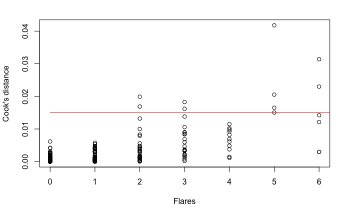

```r
plot(solar.flares$sum.of.flares.production.by.this.region.24.hours, cooks.distance(model4), xlab="Flares", ylab="Cook's distance")
lines(c(0,100), c(0.015, 0.015), col="red")
```

[output not shown]

```r
solar.flares.modified2 <- solar.flares.modified[cooks.distance(model4)<0.15,]
model5 <- model3 <- glm(sum.of.flares.production.by.this.region.24.hours~.-spot.distribution.X+Historically.complex:Did.region.become.historically.complex.on.this.pass.across.the.sun.s.disk,family = negative.binomial(theta = 1), data = solar.flares.modified2)
res <- cbind(coefficients(model4), coefficients(model5))
colnames(res) <- c("All data", "Filtered data")
res
```

```
                                                                                                    All data
(Intercept)                                                                                    -17.576177289
modified.Zurich.class.C                                                                         16.364170837
modified.Zurich.class.D                                                                         16.868373875
modified.Zurich.class.E                                                                         17.545391134
modified.Zurich.class.F                                                                         17.332805809
modified.Zurich.class.H                                                                         14.773387604
largest.spot.size.H                                                                             -0.465840000
largest.spot.size.K                                                                              0.680280706
largest.spot.size.R                                                                             -0.526583348
largest.spot.size.S                                                                              0.006243822
largest.spot.size.X                                                                             15.258304395
spot.distribution.I                                                                             -0.136362449
spot.distribution.O                                                                             -0.474308073
Activity                                                                                         0.181108366
Evolution                                                                                        0.213503245
Previous.24.hour.flare.activity.code                                                             0.139660912
Historically.complex                                                                             0.003714898
Did.region.become.historically.complex.on.this.pass.across.the.sun.s.disk                      -15.161535380
Area                                                                                            -0.342910975
Historically.complex:Did.region.become.historically.complex.on.this.pass.across.the.sun.s.disk  15.440275727
                                                                                               Filtered data
(Intercept)                                                                                    -17.576177289
modified.Zurich.class.C                                                                         16.364170837
modified.Zurich.class.D                                                                         16.868373875
modified.Zurich.class.E                                                                         17.545391134
modified.Zurich.class.F                                                                         17.332805809
modified.Zurich.class.H                                                                         14.773387604
largest.spot.size.H                                                                             -0.465840000
largest.spot.size.K                                                                              0.680280706
largest.spot.size.R                                                                             -0.526583348
largest.spot.size.S                                                                              0.006243822
largest.spot.size.X                                                                             15.258304395
spot.distribution.I                                                                             -0.136362449
spot.distribution.O                                                                             -0.474308073
Activity                                                                                         0.181108366
Evolution                                                                                        0.213503245
Previous.24.hour.flare.activity.code                                                             0.139660912
Historically.complex                                                                             0.003714898
Did.region.become.historically.complex.on.this.pass.across.the.sun.s.disk                      -15.161535380
Area                                                                                            -0.342910975
Historically.complex:Did.region.become.historically.complex.on.this.pass.across.the.sun.s.disk  15.440275727
```

## 4. Интепретация коэффициентов

```r
print(exp(coefficients(model4)))
```

```
                                                                                   (Intercept)
                                                                                  2.326822e-08
                                                                       modified.Zurich.class.C
                                                                                  1.278996e+07
                                                                       modified.Zurich.class.D
                                                                                  2.117589e+07
                                                                       modified.Zurich.class.E
                                                                                  4.167413e+07
                                                                       modified.Zurich.class.F
                                                                                  3.369317e+07
                                                                       modified.Zurich.class.H
                                                                                  2.606158e+06
                                                                           largest.spot.size.H
                                                                                  6.276077e-01
                                                                           largest.spot.size.K
                                                                                  1.974432e+00
                                                                           largest.spot.size.R
                                                                                  5.906195e-01
                                                                           largest.spot.size.S
                                                                                  1.006263e+00
                                                                           largest.spot.size.X
                                                                                  4.232504e+06
                                                                           spot.distribution.I
                                                                                  8.725263e-01
                                                                           spot.distribution.O
                                                                                  6.223155e-01
                                                                                      Activity
                                                                                  1.198545e+00
                                                                                     Evolution
                                                                                  1.238008e+00
                                                          Previous.24.hour.flare.activity.code
                                                                                  1.149884e+00
                                                                          Historically.complex
                                                                                  1.003722e+00
                     Did.region.become.historically.complex.on.this.pass.across.the.sun.s.disk
                                                                                  2.602728e-07
                                                                                          Area
                                                                                  7.097014e-01
Historically.complex:Did.region.become.historically.complex.on.this.pass.across.the.sun.s.disk
                                                                                  5.077227e+06
```

## 5. Доверительные интервалы для коэффициентов

```r
print(exp(coefficients(model4)))
```

```
                                                                                   (Intercept)
                                                                                  2.326822e-08
                                                                       modified.Zurich.class.C
                                                                                  1.278996e+07
                                                                       modified.Zurich.class.D
                                                                                  2.117589e+07
                                                                       modified.Zurich.class.E
                                                                                  4.167413e+07
                                                                       modified.Zurich.class.F
                                                                                  3.369317e+07
                                                                       modified.Zurich.class.H
                                                                                  2.606158e+06
                                                                           largest.spot.size.H
                                                                                  6.276077e-01
                                                                           largest.spot.size.K
                                                                                  1.974432e+00
                                                                           largest.spot.size.R
                                                                                  5.906195e-01
                                                                           largest.spot.size.S
                                                                                  1.006263e+00
                                                                           largest.spot.size.X
                                                                                  4.232504e+06
                                                                           spot.distribution.I
                                                                                  8.725263e-01
                                                                           spot.distribution.O
                                                                                  6.223155e-01
                                                                                      Activity
                                                                                  1.198545e+00
                                                                                     Evolution
                                                                                  1.238008e+00
                                                          Previous.24.hour.flare.activity.code
                                                                                  1.149884e+00
                                                                          Historically.complex
                                                                                  1.003722e+00
                     Did.region.become.historically.complex.on.this.pass.across.the.sun.s.disk
                                                                                  2.602728e-07
                                                                                          Area
                                                                                  7.097014e-01
Historically.complex:Did.region.become.historically.complex.on.this.pass.across.the.sun.s.disk
                                                                                  5.077227e+06
```

```r
exp(confint.default(model4))
```

```
                                                                                                   2.5 %    97.5 %
(Intercept)                                                                                    0.0000000       Inf
modified.Zurich.class.C                                                                        0.0000000       Inf
modified.Zurich.class.D                                                                        0.0000000       Inf
modified.Zurich.class.E                                                                        0.0000000       Inf
modified.Zurich.class.F                                                                        0.0000000       Inf
modified.Zurich.class.H                                                                        0.0000000       Inf
largest.spot.size.H                                                                            0.2493941 1.5793933
largest.spot.size.K                                                                            1.0784478 3.6148076
largest.spot.size.R                                                                            0.3510691 0.9936259
largest.spot.size.S                                                                            0.6728000 1.5050030
largest.spot.size.X                                                                            0.0000000       Inf
spot.distribution.I                                                                            0.4568586 1.6663849
spot.distribution.O                                                                            0.3038033 1.2747610
Activity                                                                                       0.8243408 1.7426168
Evolution                                                                                      0.9444815 1.6227556
Previous.24.hour.flare.activity.code                                                           0.8261620 1.6004523
Historically.complex                                                                           0.6847874 1.4711975
Did.region.become.historically.complex.on.this.pass.across.the.sun.s.disk                      0.0000000       Inf
Area                                                                                           0.3125900 1.6112995
Historically.complex:Did.region.become.historically.complex.on.this.pass.across.the.sun.s.disk 0.0000000       Inf
```